# Dataset, EDA and research question

Marion Nyberg & Rachel Han

28/02/2020

# Data Description

The [dataset](https://www.kaggle.com/datasnaek/youtube-new) `Trending YouTube Video Statistics’ is put together by [Mitchell Jolly](https://mitchelljolly.com/) from YouTube API, which was has records from 2008 and was last updated on 2019-06-02. The scripts that scraped the data from YouTube API can be found [here](https://github.com/mitchelljy/Trending-YouTube-Scraper), and the primary aim of the dataset is for use in determining the year’s top trending Youtube videos.

There are 10 datasets presented specific to the following countries: USA, Great Britain, Germany, Canada, France, Russia, Mexico, South Korea, Japan and India. We choose the Canada dataset to explore. The dataset contains rows of trending videos which include features like category, trending date, tags, number of views, likes, dislikes, shares and descriptions of videos.

```r
# read Canada dataset csv file
CAN <- read.csv(file = 'data/CAvideos.csv')
```

In this dataset, there are 40881 observations and 16 features.

```r
nrow(CAN)
```

```
## [1] 40881
```

```r
ncol(CAN)
```

```
## [1] 16
```

The following are tye data types of the sixteen columns in the dataset.

```r
features <- CAN %>% colnames() %>% as_tibble()
types <- CAN %>% sapply(class) %>% as_tibble()
feature_type <- cbind(features,types)
colnames(feature_type)<-c("Features","Type")
kable(feature_type)
```

| Features | Type |
| --- | --- |
| video_id | factor |
| trending_date | factor |
| title | factor |
| channel_title | factor |
| category_id | integer |
| publish_time | factor |
| tags | factor |
| views | integer |
| likes | integer |
| dislikes | integer |
| comment_count | integer |
| thumbnail_link | factor |
| comments_disabled | factor |
| ratings_disabled | factor |
| video_error_or_removed | factor |
| description | factor |

For some columns like title, tags and description, it makes more sense for its data class to be `char` instead of `factor`. This may be part of the data grooming process.

# EDA

We plot of trend between likes and views:

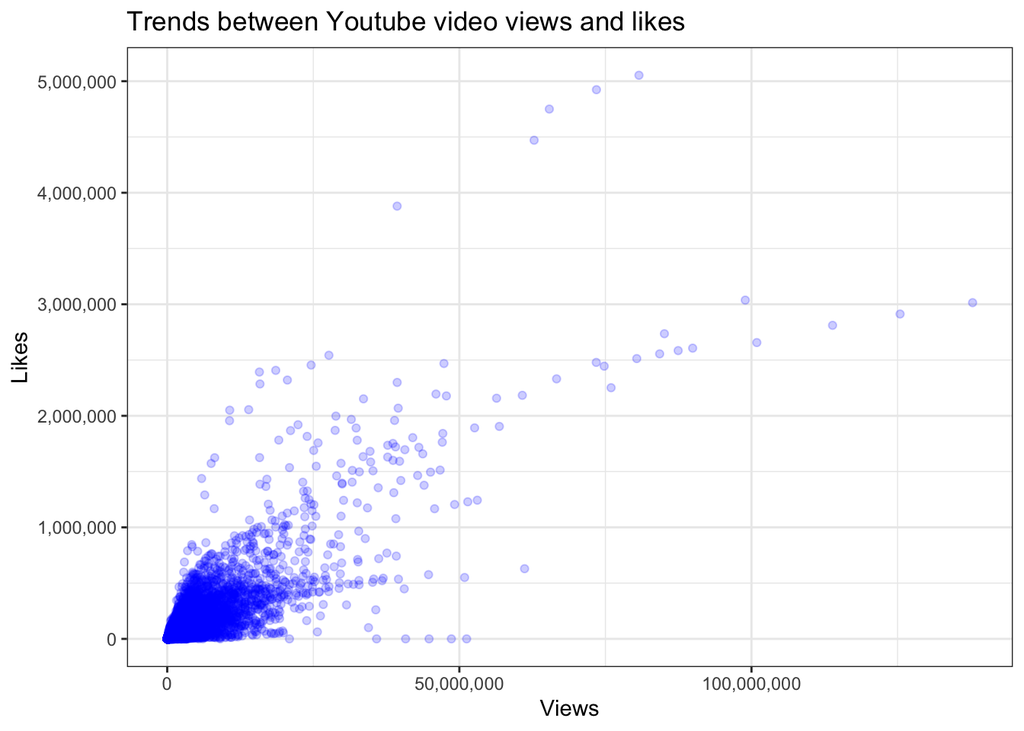

```r
ggplot(CAN, aes(views, likes)) +
  geom_point(alpha =0.2,position="jitter", color = "blue") +
  scale_x_continuous(labels = scales::comma_format()) +
  scale_y_continuous(labels = scales::comma_format()) +
  labs(x = "Views", y = "Likes") +
  ggtitle("Trends between Youtube video views and likes")+
  theme_bw()
```

We see that in general the number of likes increase as we have more views. The points are concentrated at the bottom left corner (there are more videos with number of views less than 50 million, and likes less than 1 million).

We explore how many videos are in each category.

```r
category_vids <- CAN %>% group_by(category_id) %>%
  tally() %>%
  arrange(desc(n))
kable(category_vids)
```

| category_id | n |
| --- | --- |
| 24 | 13451 |
| 25 | 4159 |
| 22 | 4105 |
| 23 | 3773 |
| 10 | 3731 |
| 17 | 2787 |
| 1 | 2060 |
| 26 | 2007 |
| 20 | 1344 |
| 28 | 1155 |
| 27 | 991 |
| 19 | 392 |
| 15 | 369 |
| 2 | 353 |
| 43 | 124 |
| 29 | 74 |
| 30 | 6 |

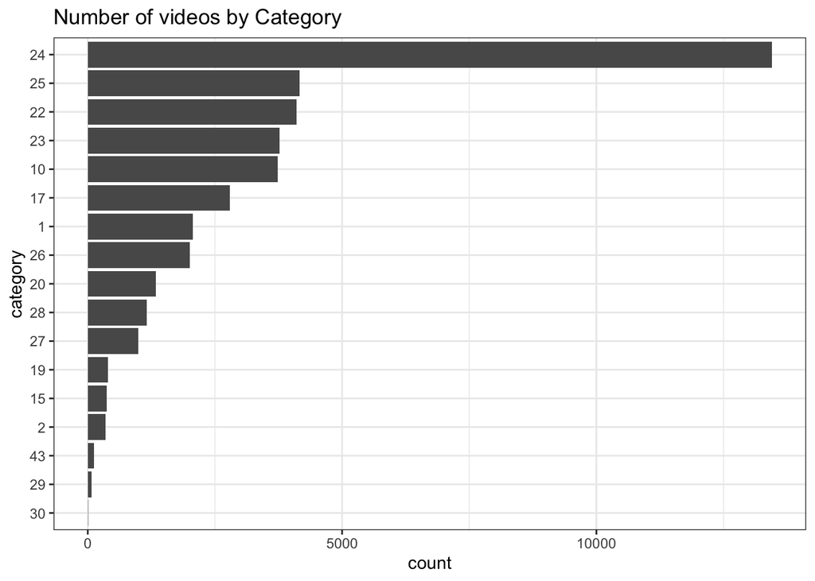

```r
category_vids %>% ggplot(aes(y=n,
             x = fct_reorder(as.factor(category_vids$category_id),
                             category_vids$n,
                             max, .incr=TRUE))) +
  geom_bar(stat="identity") +
  coord_flip() +
  ylab("count") +
  xlab("category") +
  theme_bw() +
  theme(legend.position = "none") +
  ggtitle("Number of videos by Category")
```

The category corresponding to its ID can be found [here](https://developers.google.com/youtube/v3/docs/videoCategories/list).

Top 5 Categories are:

- Category 24: Entertainment
- Category 25: News and Politics
- Category 22: People and Blogs
- Category 23: Comedy
- Category 10: Music

Bottom 5 Categories are:

- Category 30: Movies
- Category 29: Nonprofits & Activism
- Category 43: Shows
- Category 2: Autos and Vehicles
- Category 15: Pets and Animals

```r
library(tidyverse)
library(corrplot)
```

Next, we explore correlation between numerical columns.

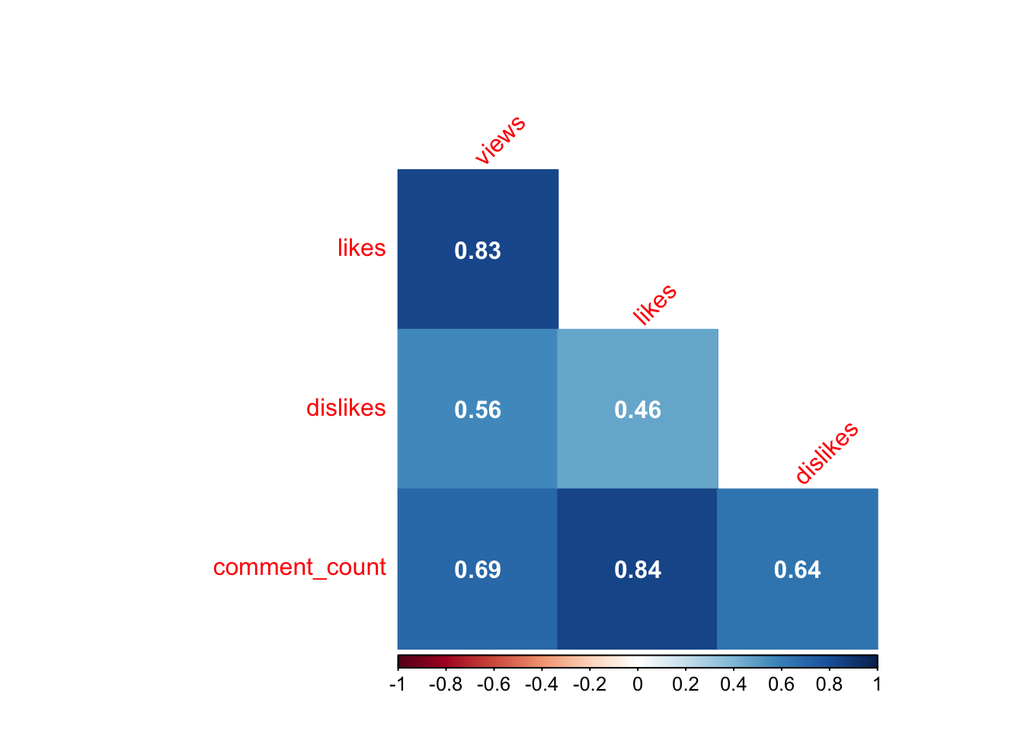

```r
CAN %>% select(views, likes, dislikes,comment_count) %>%
  cor() %>%
  round(2) %>%
  corrplot(
    type="lower",
    method="color",
    tl.srt=45,
    addCoef.col = "white",
    diag = FALSE)
```

Here we compute the mean views, likes, dislikes and comment counts for video category.

```r
category.agg <- aggregate(CAN[,8:11],
                         by = list(CAN$category_id),
                        FUN = mean) %>%
  rename(category_id = Group.1)

category.agg$category_id <- as.factor(category.agg$category_id)

kable(category.agg)
```

| category_id | views | likes | dislikes | comment_count |
| --- | --- | --- | --- | --- |
| 1 | 1426728.6 | 37767.963 | 1510.3199 | 4896.3947 |
| 2 | 566759.4 | 13405.422 | 560.2720 | 2878.7195 |
| 10 | 3532524.8 | 151285.856 | 5922.8598 | 14053.9405 |
| 15 | 638461.2 | 23931.534 | 501.3631 | 4941.8374 |
| 17 | 1075583.8 | 21330.972 | 1179.1780 | 2748.9566 |
| 19 | 366701.4 | 9568.658 | 331.2781 | 1556.0026 |
| 20 | 923759.2 | 38487.018 | 1820.5967 | 7191.1362 |
| 22 | 786413.6 | 25673.219 | 2309.5727 | 4097.0039 |
| 23 | 982888.6 | 51960.422 | 1423.9372 | 5205.0824 |
| 24 | 1016371.7 | 28789.342 | 1917.4473 | 4112.1876 |
| 25 | 388220.7 | 7863.682 | 784.8139 | 2226.4458 |
| 26 | 782683.9 | 25502.294 | 862.2422 | 4156.9093 |
| 27 | 536602.8 | 21162.868 | 800.6539 | 2995.3744 |
| 28 | 1233844.5 | 37068.916 | 1550.7818 | 6241.7481 |
| 29 | 1562184.1 | 138413.689 | 31429.8243 | 43547.8514 |
| 30 | 2853415.0 | 42150.833 | 2046.6667 | 2329.8333 |
| 43 | 577012.2 | 4752.121 | 971.2581 | 622.9274 |

[figure not shown]

```r
category.agg %>%
  arrange(desc(views)) %>%
  top_n(10) %>%
  ggplot(aes(likes, views)) +
  geom_point(aes(color = category_id)) +
  labs(x = "Likes", y= "Views") +
  scale_x_continuous(labels = scales::comma_format()) +
  scale_y_continuous(labels = scales::comma_format()) +
  ggtitle( "Mean video views and likes for the top 10 most viewed video categories") +
  theme_bw()
```

# Research questions

What is the relationship between video category, number of views it recieves, likes/dislikes and comment count?

- Does the number of comment counts on Youtube videos correlate with the number of likes or dislikes on a video?
- What trends exist between comment count and video likes/dislikes

# Plan of action

With our research questions we are mainly interested in the comment counts, likes, dislikes, views, and how these change over time. Hence we will perform subsequent analysis using this reduced dataset, after dealing with any missing values. To investigate the questions we will plot time series of the data to visualise trends in variables over time as well as perform both simple and multiple linear regression analysis to estimate the relationship between variables.